# Drivers of sample number

Engagement team - Freshawater Hackathon

25-27 May 2017

# Introduction

We want to know what the drivers of more samples is. We think this might be driven by things like the type of training they got, the amount and types of social engagement, length of involvement, etc.

# Data

The data were provided in .csv format. These were read in and some columns were fixed. The data was saved then as a `.rdata` which we read in here

Looking at the data we need to look out for NAs and skew as well as the fact that our samples counts are zero inflated and skewed.

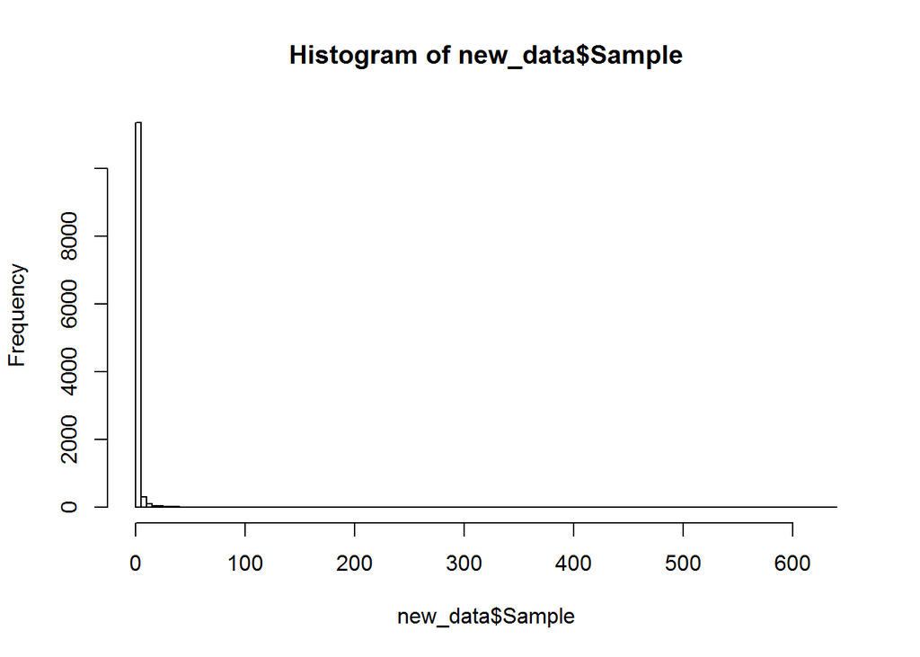

```r
# We have a zero inflation problem
hist(new_data$Sample, breaks = 100)
```

```r
# get rid of zeros
new_data_noZeros <- new_data[new_data$Sample > 0 & new_data$ActivePeriod > 0 & new_data$Staff == 0, ]

# How much data do we have for the covariates of interest?
nrow(new_data_noZeros)
```

```
## [1] 1323
```

```r
summary(new_data_noZeros[, c('ActivePeriod', 'Paid','Staff','PCA1_Difficulty', 'WQS', 'Com_score', 'Skill_score', 'Team')])
```

```
##   ActivePeriod          Paid            Staff     PCA1_Difficulty
##  Min.   :    1.0   Min.   :0.0000   Min.   :0     Min.   :-1.0279
##  1st Qu.:   80.0   1st Qu.:0.0000   1st Qu.:0     1st Qu.:-0.7625
##  Median :  193.0   Median :0.0000   Median :0     Median :-0.1132
##  Mean   :  298.6   Mean   :0.4884   Mean   :0     Mean   : 0.1167
##  3rd Qu.:  382.0   3rd Qu.:1.0000   3rd Qu.:0     3rd Qu.: 0.9710
##  Max.   :10958.0   Max.   :1.0000   Max.   :0     Max.   : 3.1795
##  NA's   :246       NA's   :678      NA's   :246   NA's   :246
##       WQS        Com_score         Skill_score           Team
##  Min.   :0     Min.   :   0.000   Min.   :  0.000   Min.   :0.0000
##  1st Qu.:0     1st Qu.:   0.000   1st Qu.:  2.000   1st Qu.:1.0000
##  Median :0     Median :   0.000   Median :  2.000   Median :1.0000
##  Mean   :0     Mean   :   7.892   Mean   :  4.698   Mean   :0.9023
##  3rd Qu.:0     3rd Qu.:   0.000   3rd Qu.:  4.000   3rd Qu.:1.0000
##  Max.   :0     Max.   :2517.000   Max.   :250.000   Max.   :1.0000
##  NA's   :246   NA's   :246        NA's   :246       NA's   :678
```

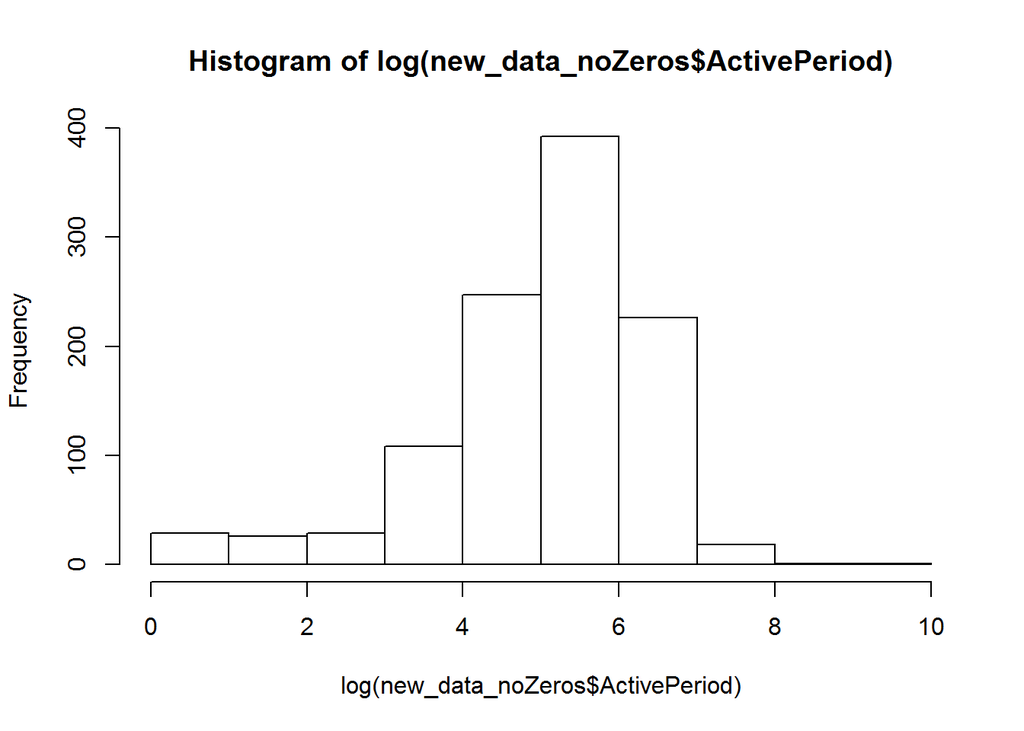

```r
# We are going to lose lots of data through NAs in the Paid column
# WQS would be great but there are so many NAs we just can't use it

# We might be best loging some of our predictor variables
hist(log(new_data_noZeros$ActivePeriod))
```

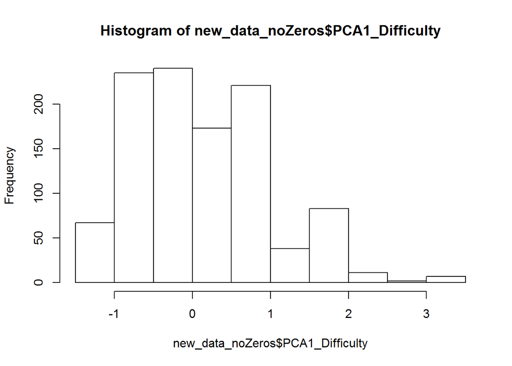

```r
hist(new_data_noZeros$PCA1_Difficulty)
```

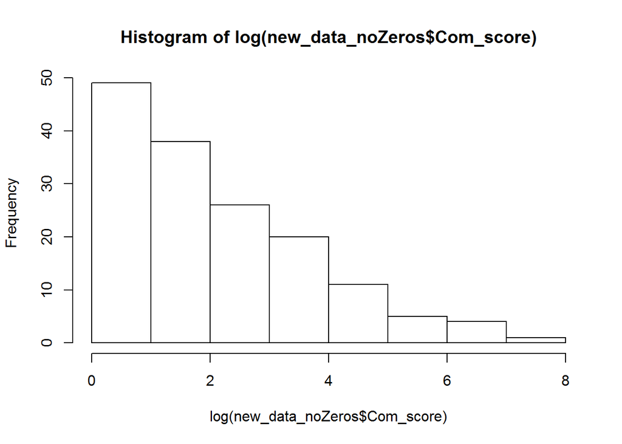

```r
hist(log(new_data_noZeros$Com_score))
```

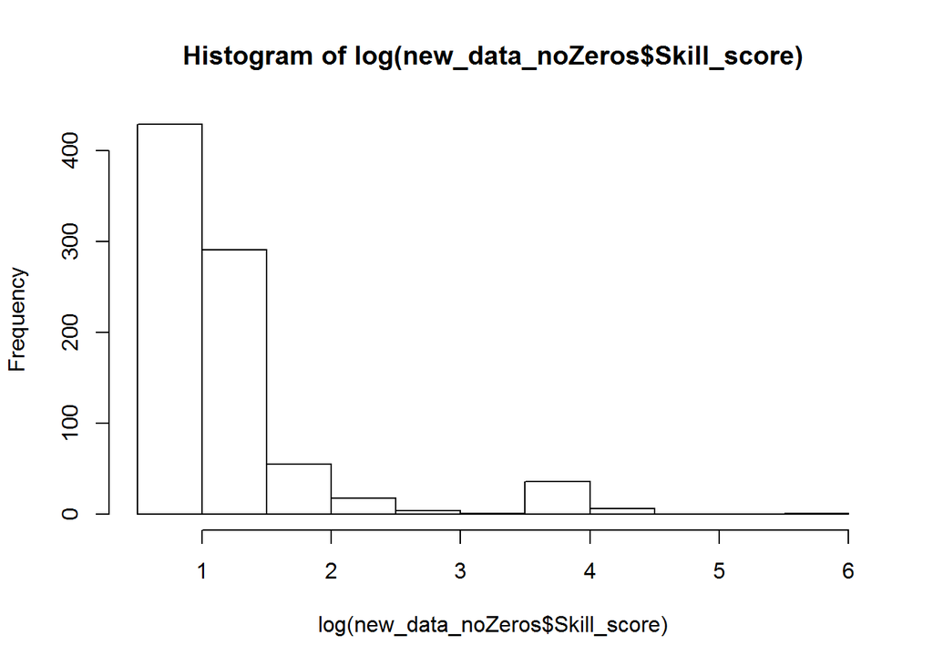

```r
hist(log(new_data_noZeros$Skill_score))
```

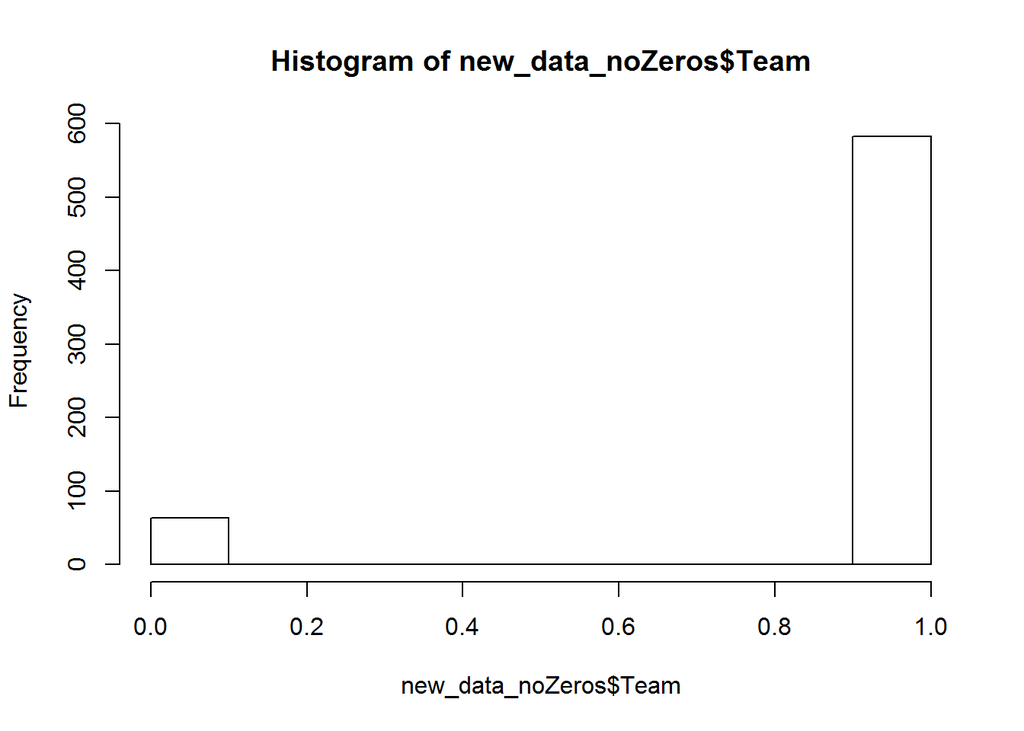

```r
hist(new_data_noZeros$Team)
```

We can use a poisson distribution to account for the skew in teh samples counts and removes 0s to deal with the zero inflation. This step is reasonable as the 0 people are not involved in the project. The explanatory variables are in some cases improved by logging.

```r
# We need to move to a mixed effects model because we want to put country in there
m3 <- glmer(Sample ~ log(ActivePeriod+1) + Paid + PCA1_Difficulty + log(Com_score+1) + log(Skill_score+1) + Team + (1|Country), data = new_data_noZeros, family = 'poisson')

summary(m3)
```

```
## Generalized linear mixed model fit by maximum likelihood (Laplace
##   Approximation) [glmerMod]
##  Family: poisson  ( log )
## Formula:
## Sample ~ log(ActivePeriod + 1) + Paid + PCA1_Difficulty + log(Com_score +
##     1) + log(Skill_score + 1) + Team + (1 | Country)
##    Data: new_data_noZeros
##
##      AIC      BIC   logLik deviance df.resid
##   8137.1   8172.8  -4060.5   8121.1      637
##
## Scaled residuals:
##    Min     1Q Median     3Q    Max
## -8.790 -1.159 -0.096  1.092 40.720
##
## Random effects:
##  Groups  Name        Variance Std.Dev.
##  Country (Intercept) 0.6063   0.7787
## Number of obs: 645, groups:  Country, 12
##
## Fixed effects:
##                       Estimate Std. Error z value Pr(>|z|)
## (Intercept)           -2.39364    0.56089   -4.27 1.98e-05 ***
## log(ActivePeriod + 1)  0.86076    0.01451   59.31  < 2e-16 ***
## Paid                   0.77761    0.04273   18.20  < 2e-16 ***
## PCA1_Difficulty        0.35866    0.01997   17.96  < 2e-16 ***
## log(Com_score + 1)     0.24198    0.01038   23.30  < 2e-16 ***
## log(Skill_score + 1)  -0.20187    0.01611  -12.53  < 2e-16 ***
## Team                  -0.56510    0.60596   -0.93    0.351
## ---
## Signif. codes:  0 '***' 0.001 '**' 0.01 '*' 0.05 '.' 0.1 ' ' 1
##
## Correlation of Fixed Effects:
##             (Intr) l(AP+1 Paid   PCA1_D l(C_+1 l(S_+1
## lg(ActvP+1) -0.153
## Paid        -0.064 -0.138
## PCA1_Dffclt  0.049  0.025 -0.434
## lg(Cm_sc+1)  0.009 -0.209  0.227  0.010
## lg(Skll_+1) -0.037  0.059 -0.078  0.047 -0.277
## Team        -0.902  0.003  0.055 -0.060  0.011  0.000
```

```r
# Adding country as a random effect has improved the model
sjp.glmer(m3)
```

```
## Plotting random effects...
```

[figure not shown]

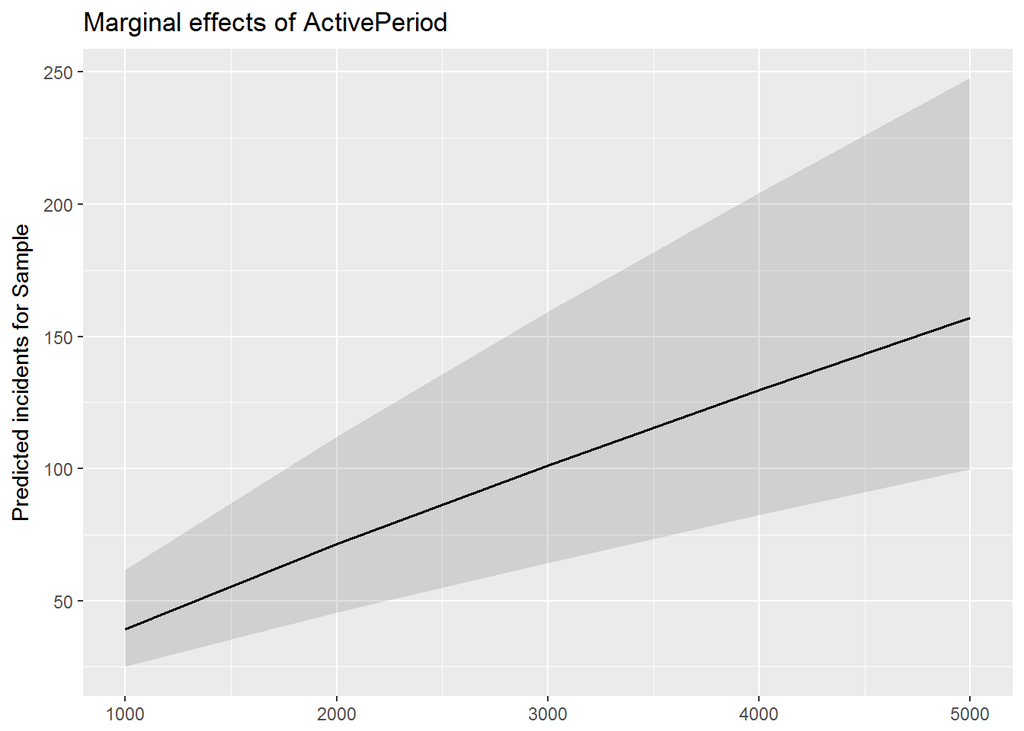

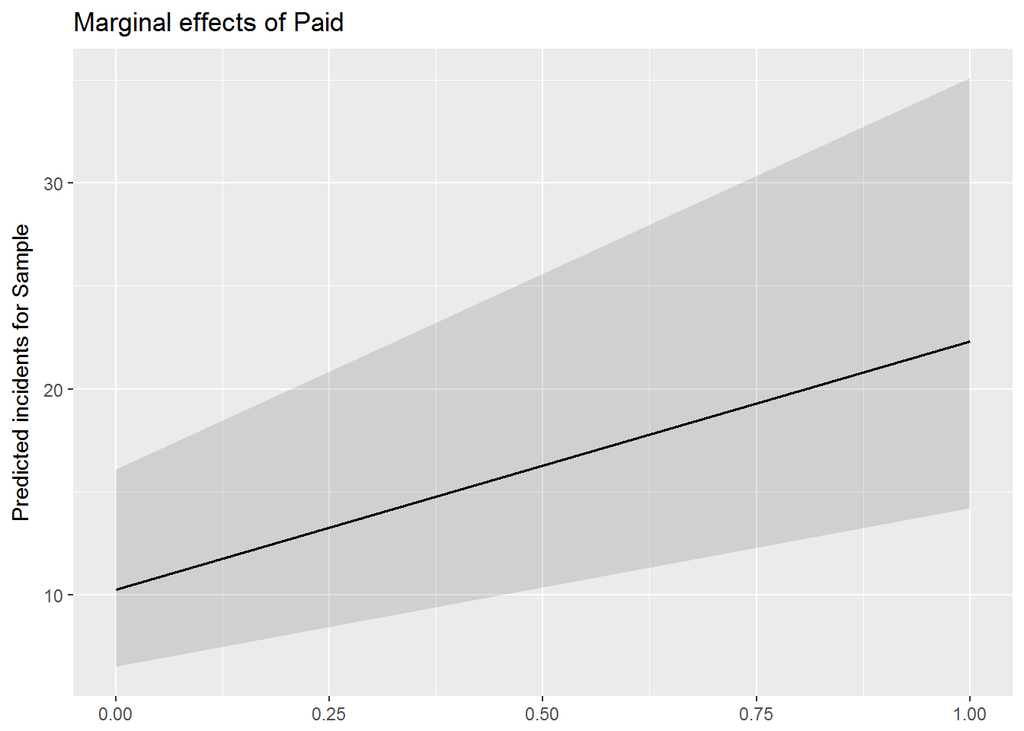

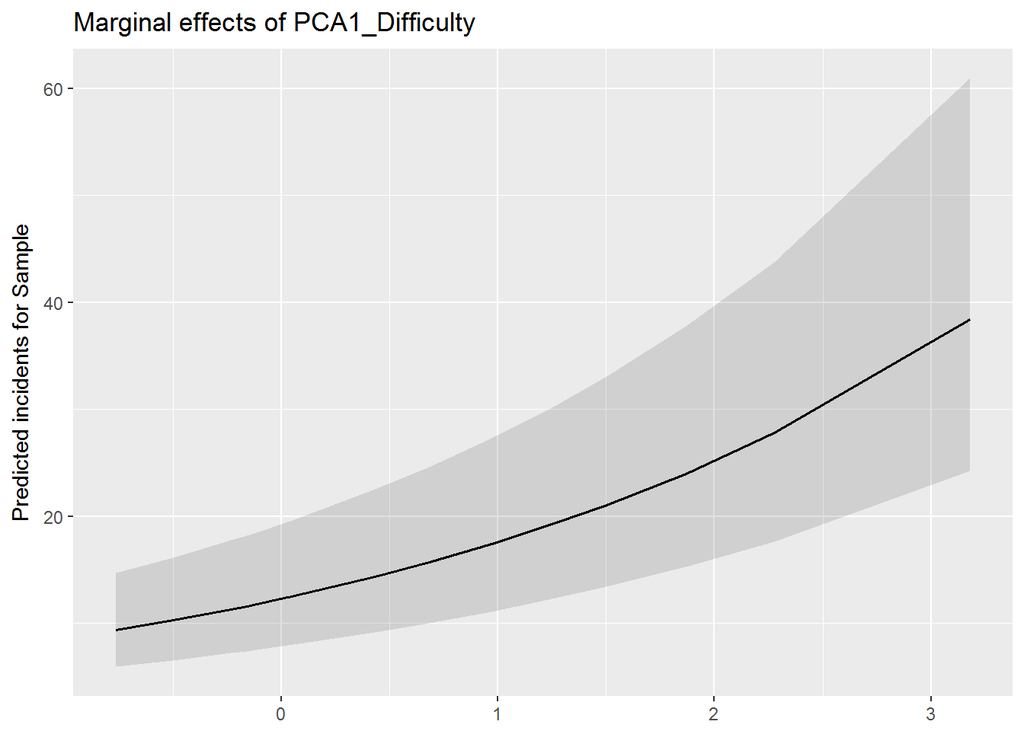

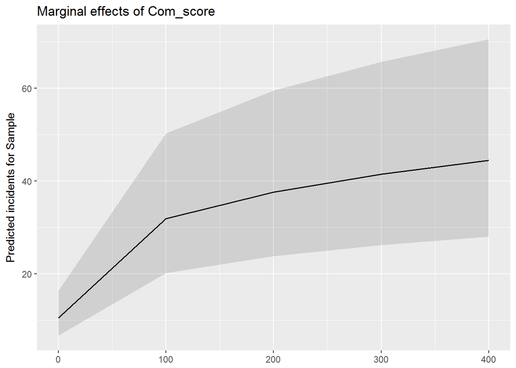

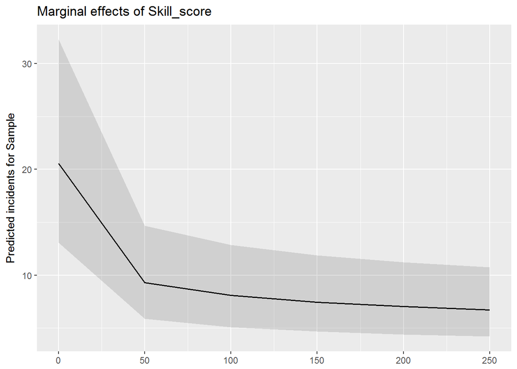

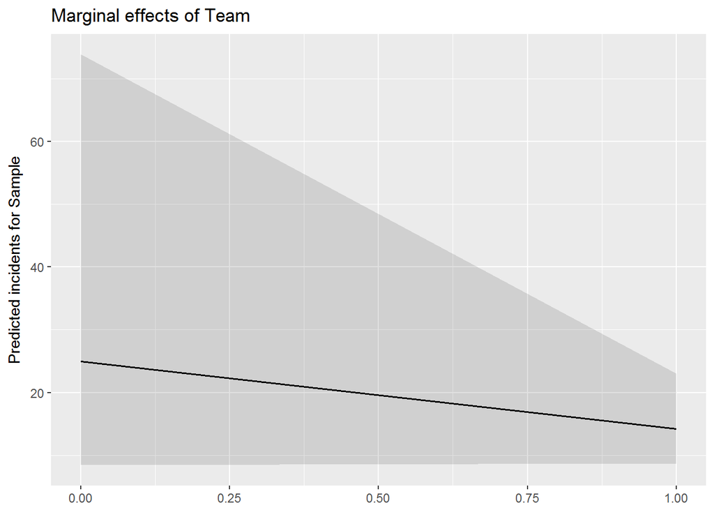

```r
sjp.glmer(m3, type = "eff",
          # axis.lim = list(c(0,50), c(0,5), c(0,5), c(0,5)),
          facet.grid = FALSE,
          show.p = TRUE,
          show.ci = TRUE)
```

The results from the mixed effects model shows that a number of parameters are important. We plot the random effect which show how the countries vary in the amount of samples they generate and we plot the fixed effects. The increasing error in these i think reflects the fact that in most cases sample size decreases as values increase.